# Homework 7

Emily Beasley

October 16, 2018

The following data sim is a little different from the instructions on the course page. I wanted to do a simulation that was more applicable to my dissertation research. I will simulate some occupancy data for ectoparasites on mammalian hosts that will eventually be used to build a multi-scale occupancy model.

Since the model will take a long time to figure out, for this assignment I’m going to demonstrate how imperfect detection can bias richness counts. Assignment 8 will involve condensing this code into a few functions and determining the minimum number of sites needed to detect all ectoparasite species

First, generate some preliminary variables.

```r
set.seed(15)

#Mammal species
mammspecs <- data.frame(as.character(seq(1:10)))
colnames(mammspecs) <- "mamm.specs"

#assign fake genera to mammals. This will be important later,
#ectos tend to be phylogenetically conserved
mammspecs$genus <- c(rep("genus1", 5), rep("genus2", 5))

#Ecto species
ectospecs <- data.frame(as.character(seq(1:12)))
colnames(ectospecs) <- "ecto.specs"
#Twelve ectoparasite species is a low-ish number, but it'll do

#Assign ectos as generalist, specialist, or neither
ectospecs$life.history <- c(rep("generalist", 4), rep("specialist", 4),
                            rep("neither", 4))
```

Generate occupancy probabilities using this nasty function.

```r
makin.data <- function(){
  #Create empty objects
  genus <- logical()
  occprobs <- matrix(NA, nrow = 12, ncol = 10)

  for(i in 1:length(ectospecs$ecto.specs)){
  #Assign a mammal genus to the ecto species
  genus[i] <- sample(mammspecs$genus, size = 1)

  #Generalist species: can occupy all species in a genus
  if(ectospecs$life.history[i] == "generalist"){
    #Generate occupancy probs for all mamm in the genus
    for(j in 1:length(mammspecs$mamm.specs)){
      if(mammspecs$genus[j] == genus[i]){
        occprobs[i,j] <- runif(1, 0, 1)
      } else{
        occprobs[i,j] <- 0
      }
    }

  #Specialist species: Only one host
  } else if(ectospecs$life.history[i] == "specialist"){
    #Generate an occupancy prob for a single host
    host <- sample(mammspecs$mamm.specs, size = 1)
    for(j in 1:length(mammspecs$mamm.specs))
      if(mammspecs$mamm.specs[j] == host){
        occprobs[i,j] <- runif(1,0,1)
      } else{
        occprobs[i,j] <- 0
      }

  #"Neither" category: one primary and one secondary host
  } else if(ectospecs$life.history[i] == "neither"){
      #Generate occupancy prob for a primary and secondary host
        sample <- sample(which(mammspecs$genus == genus[i]), 2)
        occprobs[i, sample[1]] <- runif(1, 0.5, 1) #primary host
        occprobs[i, sample[2]] <- runif(1, 0, 0.5) #secondary host
        occprobs[is.na(occprobs)] <- 0
  }
  }
  return(occprobs)
}

some.data <- makin.data()
```

Now I have occupancy data for each host species. The problem: for the multiscale model to work, I need to treat each host population as a site. So I’ll draw a probability for each population using the host species probability as a mean.

```r
#Decide how many physical sites to "sample" from
n.site <- 20 #This is ususally the minimum for an effective abundance model

#Create a vector with the name of each host population
write.names <- function(x){
  spec.names <- logical(length = length(x))
  for(i in 1:length(x)){
    spec.names[i] <- as.character(paste("Spec",x[i], sep = ""))
  }
  return(spec.names)
}

write.sites <- function(x){
  site.names <- logical(length = x)
  for(i in 1:x){
    site.names[i] <- as.character(paste("Site",i,sep = ""))
  }
  return(site.names)
}

write.ectos <- function(x){
  ectos <- logical()
  for(i in 1:length(x)){
    ectos[i] <- paste("Ecto",i, sep = "")
  }
  return(ectos)
}

ectos <- write.ectos(x = ectospecs$ecto.specs)
names <- write.names(x = mammspecs$mamm.specs)
sites <- write.sites(x = n.site)

#Generate an occupancy prob for each host population based on
#the species-level occupancy prob
spec.probs.array <- function(x,y,z){
pop.array <- array(dim = c(length(x), y,length(z)))

for(i in 1:length(x)){
  for(j in 1:y){
    for(k in 1:length(z)){
      if(some.data[k,i] != 0){
          pop.array[i,j,k] <- rtnorm(n = 1, mean = some.data[k,i], sd = 0.05,
                                    lower = 0, upper = 1)
        #Use a truncated normal distribution to make sure it's a probability
        #May use a different distribution later
      } else{
        pop.array[i,j,k] <- 0
    }
  }
  }
}
return(pop.array)
}

poparray <- spec.probs.array(x = mammspecs$mamm.specs, y = n.site,
                            z = ectospecs$ecto.specs)

#Function to convert array into data frame
spec.probs.mat <- function(x){
  popoccs <- matrix(NA, nrow = dim(x)[1]*dim(x)[2], ncol = dim(x)[3])
  for(i in 1:dim(x)[3]){
    popoccs[,i] <- as.vector(x[,,i])
  }
  popoccs <- as.data.frame(popoccs)
  return(popoccs)
}

popmat <- spec.probs.mat(x = poparray)
```

Use the occupancy probabilities to generate sample presence-absence data.

```r
get.occs <- function(x){
  occstate <- matrix(NA, nrow = length(x[,1]), ncol = length(x[1,]))
  for(i in 1:length(x[,1])){
    for(j in 1:length(x[1,])){
      occstate[i,j] <- rbernoulli(n = 1, p = popmat[i,j])
      occstate[which(occstate[i,j] == TRUE)] <- 1
      occstate[which(occstate[i,j] == FALSE)] <- 0
    }
  }
  return(occstate)
}

occstate <- get.occs(x = popmat)

#Now combine all of this nonsense into a single data frame
many.names <- expand.grid(names, sites)

occ.mat <- cbind(many.names, occstate)
colnames(occ.mat) <- c("Mammal", "Site", ectos)
```

Next, I need to model the sampling process. I will treat individual hosts as replicates of the population. The mammal abundance data comes from a simulated multi-species abundance model, not shown in this file.

```r
#Read in mammal data
mamms <- readRDS(file = "truemamm.RDS")

#Sample from a smaller number of sites
mamm.sites <- sample(seq(length(mamms[1,])), size = n.site, replace = F)
mammZ <- mamms[,mamm.sites]

#Simulate mean detection prob for each ectoparasite
#Same det prob regardless of host species
ecto.dets <- runif(n = length(ectos), min = 0, max = 0.2)
#Detection probs for ectoparasites in reality are usually low
#Parasites also tend to aggregate, but for now I'm not messing with that

#Create vector with numbers of sampling events K
Ks <- as.vector(mammZ)
maxK <- max(Ks)

#Create detection histories
L <- list()

for(i in 1:length(ectos)){
  y <- matrix(NA, nrow = length(Ks), ncol = maxK)
  for(k in 1:length(Ks)){
    for(j in 1:Ks[k]){
      y[k,j] <- as.numeric(rbernoulli(n = 1, p = ecto.dets[i]*occstate[k,i]))
    }
  }
  L[[i]] <- y
}

#Change list of matrices into array
obsdata<-array(unlist(L), dim=c(length(Ks), maxK, length(ectos)))
#Change NA to 0
obsdata[is.na(obsdata)] <- 0

#Add all observed occurances; if there is more than 1, change to 1
obsdata2 <- apply(obsdata, c(1,3), sum)
obsdata2[obsdata2 >= 1] <- 1

#Turn matrix into a data.frame and name the columns
obsdata2 <- as.data.frame(obsdata2)

#bind the observation data with site and species names
obsmat <- bind_cols(many.names, obsdata2)
#Rename columns
colnames(obsmat) <- c("Mammal", "Site", ectos)
```

Determine site-level and host-level ectoparasite richness

```r
#Coerce into long format
longdat <- function(x){
  x %>%
    gather(Ecto1:Ecto12, key = "Ecto", value = "PresAbs")
}

long.occ <- longdat(x = occ.mat)
long.obs <- longdat(x = obsmat)

print(head(long.occ))
```

```
##   Mammal  Site  Ecto PresAbs
## 1  Spec1 Site1 Ecto1       1
## 2  Spec2 Site1 Ecto1       0
## 3  Spec3 Site1 Ecto1       0
## 4  Spec4 Site1 Ecto1       0
## 5  Spec5 Site1 Ecto1       0
## 6  Spec6 Site1 Ecto1       0
```

```r
print(head(long.obs))
```

```
##   Mammal  Site  Ecto PresAbs
## 1  Spec1 Site1 Ecto1       0
## 2  Spec2 Site1 Ecto1       0
## 3  Spec3 Site1 Ecto1       0
## 4  Spec4 Site1 Ecto1       0
## 5  Spec5 Site1 Ecto1       0
## 6  Spec6 Site1 Ecto1       0
```

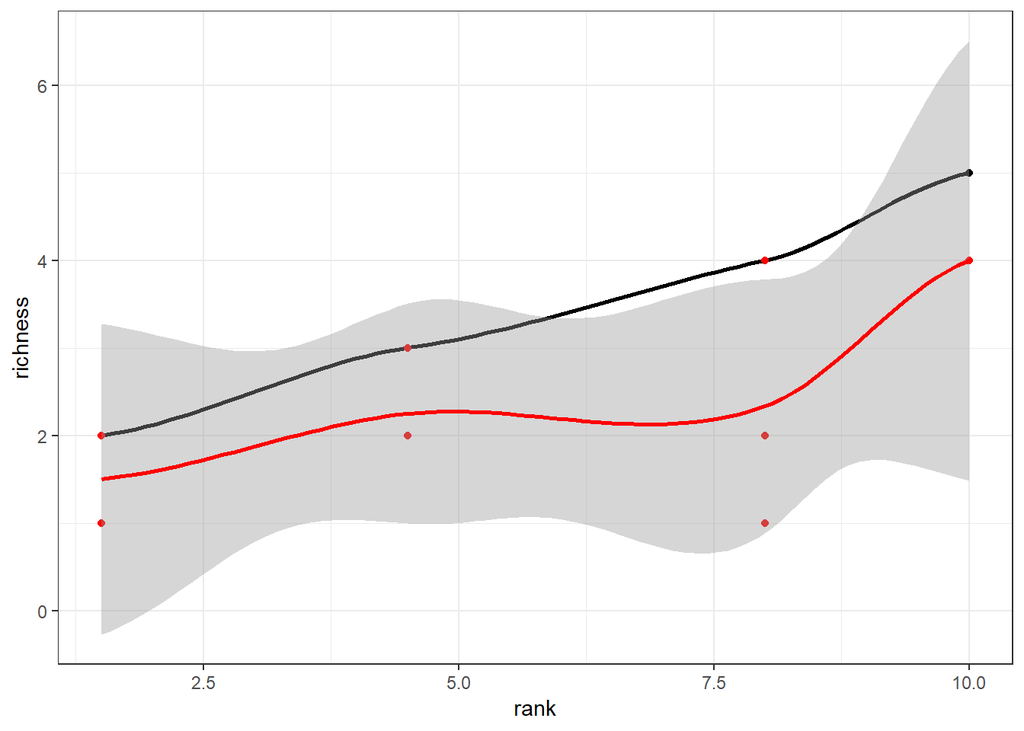

```r
#Get richness counts by species
spec.richness <- function(x){
  x %>%
    group_by(Mammal, Ecto) %>%
    summarize(counts = sum(PresAbs)) %>%
    ungroup() %>%
    {. ->> temp}

  temp$counts[which(temp$counts >= 1)] <- 1
  temp %>%
    group_by(Mammal) %>%
    summarize(richness = sum(counts)) %>%
    {. ->> rich}

  return(rich)
}

spec.occ <- spec.richness(x = long.occ)
spec.obs <- spec.richness(x = long.obs)

#Put into one data.frame and order by true richness
spec.rich <- data.frame(rank = rank(spec.occ$richness), spec.occ, spec.obs[,2])

#plot it
ggplot(data = spec.rich, aes(x = rank))+
  geom_point(aes(y = richness, color = I("Black")))+
  geom_smooth(aes(y = richness, color = I("Black")))+
  geom_point(aes(y = richness.1, color = I("Red")))+
  geom_smooth(aes(y = richness.1, color = I("Red")))+
  theme_bw()
```

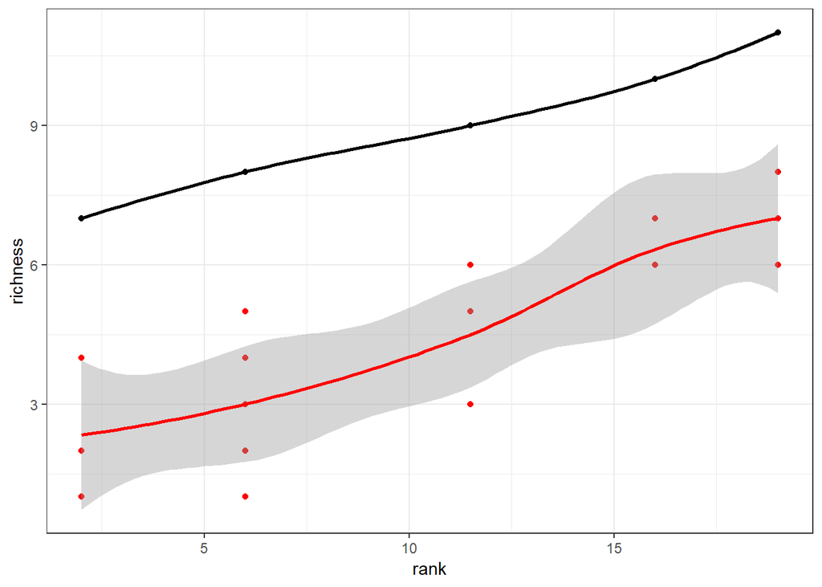

```r
#Richness counts by site
site.richness <- function(x){
    x %>%
    group_by(Site, Ecto) %>%
    summarize(counts = sum(PresAbs)) %>%
    ungroup() %>%
    {. ->> temp}

  temp$counts[which(temp$counts >= 1)] <- 1
  temp %>%
    group_by(Site) %>%
    summarize(richness = sum(counts)) %>%
    {. ->> rich}

  return(rich)
}

site.occ <- site.richness(x = long.occ)
site.obs <- site.richness(x = long.obs)

#Put into one data.frame and order by true richness
site.rich <- data.frame(rank = rank(site.occ$richness), site.occ, site.obs[,2])

#Plot it again
ggplot(data = site.rich, aes(x = rank))+
  geom_point(aes(y = richness, color = I("Black")))+
  geom_smooth(aes(y = richness, color = I("Black")))+
  geom_point(aes(y = richness.1, color = I("Red")))+
  geom_smooth(aes(y = richness.1, color = I("Red")))+
  theme_bw()
```

Based on these graphs, even with repeated sampling, detection error can reduce species richness counts, with a more pronounced effect on site-level richness.